# An exploratory report: analyzing juvenile snowshoes hares in Bonanza Creek Experimental Forest

Trevor Maggart

November 10, 2021

### 1. Overview

This exploratory report provides insight into juvenile snowshoe hares (*Lepus americanus*) from the Bonanza Creek Long Term Ecological Research Site in the Tanana Valley of Alaska from 1999 to 2012 (Kielland et al. 2017). Snowshoe hares are ‘keystone’ prey species in northern boreal forests, and experience population fluctuations every 8-11 years.

Population data for this report was collected at three sites: Bonanza Riparian (Bonrip), Bonanza Mature (Bonmat), and a lowland black spruce stand (Bonbs). Various aspects of the data are explored below, ranging from summary statistics on weight data (mean, median, etc.) to the relationship between juvenile hare hindfoot length and weight. These traits are analyzed across sex.

### 2. Data and methods

The data for this report was collected by Knut Kielland and colleagues and is available through the EDI data portal (Kielland et al. 2017). The set includes 14 variables for 378 individual observations. Each observation represents a trapped snowshoe hare and contains data on the date, location, sex, age, weight, and hindfoot length. Within the analysis we include a visualization of annual hare trappings over time, as well as a visual comparison between male and female weights. Moreover, we analyze this comparison between males and females through two-sample t-tests using a significance level ($\alpha$) of 0.05 throughout. Differences between groups are described by Cohen’s *d* effect size. The relationship between weight and hind foot length is explored using simple linear regression and Pearson’s r correlation. All analyses are in R Studio version 1.4.1717 and R version 4.1.1.

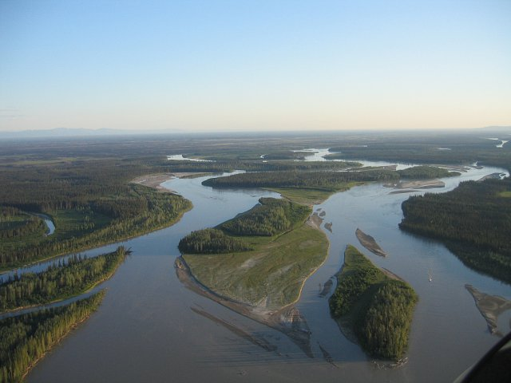

**Figure 1.** Aerial image of the Bonanza Creek Experimental Forest, home to the keystone species snowshoe hares (*Lepus americanus*) (Credit: Roger Reuss)

### 3. Preliminary results

##### Annual juvenile hare traps

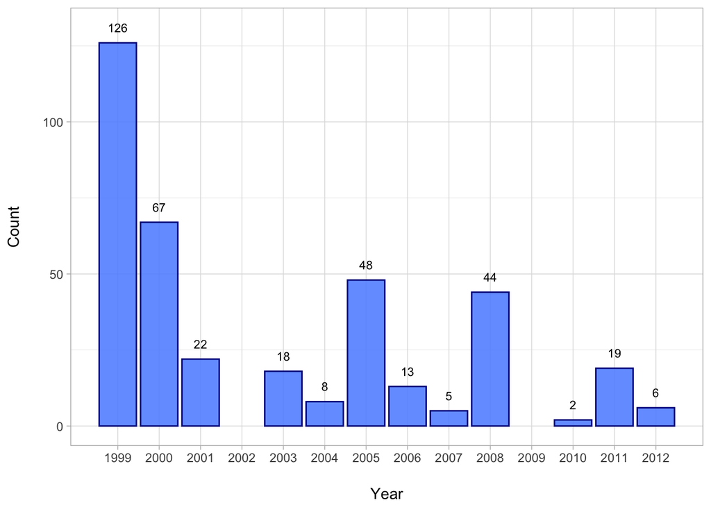

**Figure 2.** Observed annual juvenile hare traps spanning the years 1999 - 2012. Columns represent the total count of observed juvenile hares across the timespan. Data: (Kielland et al. 2017).

##### Descriptive statistics pertaining to hare counts

**Table 1.** Summary of juvenile hare trap count statistics

| Mean (Count) | Median (Count) | Standard Deviation (Count) | Max (Count) | Min (Count) |
| --- | --- | --- | --- | --- |
| 31.5 | 18.5 | 35.9 | 126 | 2 |

Juvenile hare populations peaked at the start of the study in 1999 with a total of 126 juvenile hare trappings. Since then, juvenile hare populations have fluctuated, but shown a general downward trend through time. Across the recorded years, mean juvenile hares was 32, standard deviation was 36, and the median was 18. Recent years have had a significant decrease in traps. This may be a result of attrition due to a variety of reasons, but to ensure accurate data collection in the future, care should be taken to promote consistent collection techniques. This can be achieved through consistent scheduling, checking traps during the same times annually, and by making sure the trap locations are consistent across years.

##### Juvenile hare weights across sex

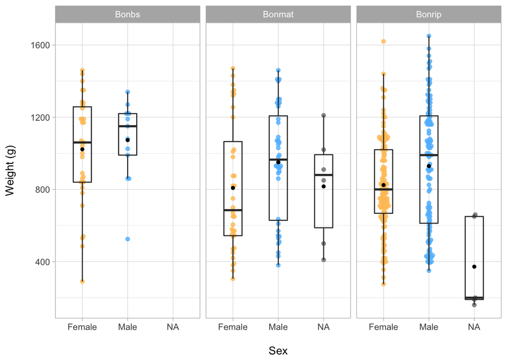

**Figure 3.** Visualization of weight (g) distribution across different sexes of juvenile hares. The data is shown across three different sites: Bonanza Riparian (Bonrip), lowland black spruce stand (Bonbs), and Bonanza Mature (Bonmat). Observations with no associated sex data are represented as NA. Box endpoints indicate the 25th and 75th percentile values; the black line and black point within the box indicate the median and mean value for each species, respectively. Data: (Kielland et al. 2017).

The graph shows that male and female hare weights differ. Male weights trend, on average, greater than female weights across all three sites. Bonrip displays the most data and is where we find the maximum weight of both male and female hares. Observations with no associated sex data are represented as NA, and are scarce across the three sites.

##### Descriptive statistics pertaining to hare weights

**Table 1.** Summary of juvenile hare weights (g) across sex

| Sex | Mean (g) | Median (g) | Standard Deviation (g) | Max (g) | Min (g) | Count |
| --- | --- | --- | --- | --- | --- | --- |
| Female | 855.39 | 825 | 292.25 | 1620 | 275 | 200 |
| Male | 945.86 | 990 | 333.22 | 1650 | 350 | 163 |
| NA | 614.55 | 650 | 357.59 | 1210 | 160 | 15 |

Assumptions of normalcy and homoscedasticity were tested using qqplot graphs and exploratory histograms. Female hare weights displayed a relatively normal distribution, but male hare weights displayed a more bimodal distribution. The mean value of male juvenile hare weights is 945.9 grams and that of female juvenile hares is 855.4 grams, which results in a difference of 90.5 grams. Considering the standard deviation in male hares weight is 333.2 grams and 292.3 grams for females, this difference appears negligible. This is corroborated by the small effect size (Cohen’s *d* = 0.29), but the two-sample t-test suggests there is a significant difference in the sample means (two-sample t-test, t = 2.71, p = 0.007).

##### Relationship between juvenile hare weights and hindfoot length

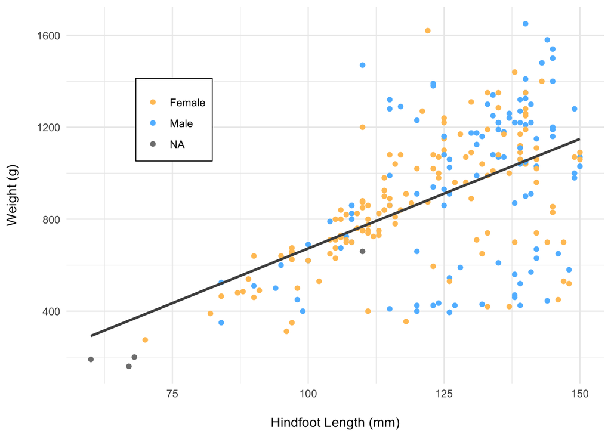

**Figure 4.** Visualization of weight (g) distribution compared to hindfoot length (mm). Female hares are represented as orange points, while male are represented as blue. Observations with no associated sex data are grey and labeled NA.

The visualization shows a simple linear regression assessing the relationship between weight (g) and hindfoot length (mm). The result is a moderate linear relationship. This linear regression shows that hindfoot length predicts snowshoe hare weight (p < 0.001, R<sup>2</sup>= 0.3) with an average slope of $\beta$ = 9.5 g mm<sup>-1</sup>. This means that with one millimeter increase in hindfoot length, we expect an average increase in hare weight of 9.5 grams. According to this linear regression, hindfoot length and hare weight are significantly positively correlated (Pearson’s *r* = 0.55, p < 0.001). In this case, the linear regression ignores if homoscedasticity is normal. Pearson’s Coefficient may not be the best value to analyze the relationship as it requires both variables to be normally distributed. However, as hindfoot length increases there appears to be increased variance in standard deviation. This, supported by exploratory plots (not shown), implies that the data is heteroscedastic and therefore a simple linear regression model does not fully and accurately reflect the relationship between weight and hindfoot length. To better understand this relationship we may have to investigate other predictor variables that may influence a hare’s weight.

### 4. Summary

This exploratory data analysis reveals the following initial findings:

- Juvenile snowshoe hare counts have decreased overall between 1999 - 2012
- There is statistically significant difference between mean male and female juvenile hare weights, although this effect size is small
- A linear regression model shows there is a positively correlated linear relationship between weight (g) and hindfoot length (mm). The relationship shows on average that with every 1 mm increase in hind foot length that hare weight will increase by 9.5 g mm<sup>-1</sup>. However, the data does not appear to be normally distributed and therefore the reliability of this model is called into question.

Next steps:

- Multiple linear regression to better understand the predictor variables that affect juvenile hare weights
- Additional data collection in the lowland black spruce stand site
- Additional analysis exploring the data for adult hares

### 5. Citation:

Kielland, K., F.S. Chapin, R.W. Ruess, and Bonanza Creek LTER. 2017. Snowshoe hare physical data in Bonanza Creek Experimental Forest: 1999-Present ver 22. Environmental Data Initiative. https://doi.org/10.6073/pasta/03dce4856d79b91557d8e6ce2cbcdc14